# Roland_Graham_DataCompetitionSubmission

Roland Graham

2023-08-18

# Fall 2022 Data Competition Submision

## Overview

The following is my submission for the Fall 2022 Data Competition while I studied at Duke University, The Fuqua School of Business. While my original submission was made via a simple R file and three individual powerpoints, I have combined all relevant code and written explanations into an R Markdown document for simplification.

The scope of the competition was to demonstrate the application of data science techniques to different areas of business. Therefore, I chose two data science techniques to pursue as part of my submission:

1. Neural Networks (A form of classification where something is labeled as either Option A or Option B)
2. Agglomerative Hierarchical Clustering (A method of grouping observations by their features)

The neural network technique was applied to a banknote forgery dataset where based on the features of forged and legitimate banknotes, my neural network could predict whether new banknotes are forgeries or not.

The hierarchical clustering technique was applied to a fictitious mall customer demographics dataset where you can identify the main segments of consumers that shop at the mall. Given that a spending score is associated with each segment, you can identify the target demographics the mall should market to.

My two projects will aim to teach people who are familiar with data science fundamentals about the usage and application of the given techniques.

## Using A Neural Network To Identify Banknote Forgeries

Banknote forgeries are harmful to banks given that:

1. They lose the banks money
2. The real value of currency at large is lowered
3. They can be passed around unknowingly, potentially implicating innocent people

Therefore, it is useful for banks to identify forgeries before they can become circulated in order to avoid the three mentioned pitfalls and potentially trace back the culprit responsible.

Using the source below, the dataset can be downloaded:

Source: https://archive.ics.uci.edu/dataset/267/banknote+authentication

Citation: Lohweg,Volker. (2013). banknote authentication. UCI Machine Learning Repository. https://doi.org/10.24432/C55P57.

The dataset contains information on 1372 grayscale pictures of banknotes. Each image is 400 x 400 pixels large.

The target variable is labelled “Class” where a value of 1 indicates the note is a forgery and a value of 0 indicates the note is legitimate.

The explanatory variables are the variance, skewness, kurtosis, and entropy of the pixel values of the grayscale images. A pixel in grayscale format is given a value ranging from 0 to 255 where 0 is all black and 255 is all white. By studying the pixel values using the grayscale format range, we can more easily detect forgeries given that legitimate banknotes may have very slight variations in designs, but forgeries will tend to have greater variations in design.

Here are the definitions on the four statistical terms for the explanatory variables:

1. Variance refers to the spread of the pixel values. High variance would see a greater number of pixel values being present in the dataset while lower variance would see a lower number of pixels in the dataset.
2. Skewness refers to the symmetricity of the pixel values where the data can be skewed to the right or left to some degree. A positive skewness value indicates skewness to the right, a negative skewness value indicates skewness to the left, and zero would be perfectly symmetrical.
3. Kurtosis refers to the sharpness of the peak of the distribution. Negative kurtosis would mean more data is centered around the mean than the tails and positive kurtosis would mean more data is contained near the tails than the mean.
4. Entropy refers to the prescence of outliers in the data where positive entropy has more outliers and negative entropy has less outliers.

```r
# Loads the neuralnet library
library(neuralnet)

# Reads in the dataset and gives the columns names
data = read.delim("/Users/rolandgraham/Downloads/data_banknote_authentication.txt", header = FALSE, sep = ",")
colnames(data)[1] = "variance"
colnames(data)[2] = "skewness"
colnames(data)[3] = "kurtosis"
colnames(data)[4] = "entropy"
colnames(data)[5] = "class"

# Standardizes the explanatory variables to assure they are measured on the
# same scale
data$variance = (data$variance - min(data$variance)) / (max(data$variance) - min(data$variance))
data$skewness = (data$skewness - min(data$skewness)) / (max(data$skewness) - min(data$skewness))
data$kurtosis = (data$kurtosis - min(data$kurtosis)) / (max(data$kurtosis) - min(data$kurtosis))
data$entropy = (data$entropy - min(data$entropy)) / (max(data$entropy) - min(data$entropy))
```

Now I will explain the purpose of neural networks and how we can use these four features to predict whether a banknote is a forgery or not.

Below is the general structure of a neural network:

[figure not shown]

The goal of neural networks is to classify observations into groups. In this case, is the banknote a forgery or legitimate? This will be accomplished through the four features discussed earlier.

You can see that there are three main parts to a neural network: the input layer, the hidden layer, and the output layer. Each circle represents a node and the number of nodes in each layer will be important in designing the neural network. The input layer will be represented by four features we will use to predict the forgeries, so in our neural network there will be four nodes in the input layer. The output layer will be represented by the variable we are predicting, in this case, the class variable. So in our neural network, there will be one node in the output layer.

The aspect of the neural network we will have to design ourselves, however, is how many levels will the hidden layer have and how many nodes will be on each level. In the example shown above, the hidden layer has three levels with four nodes each, however we can adjust those numbers for our neural network.

Ideally, the number of levels should be either one or two for data with a low amount of explanatory variables and between three to five for data with a high amount of explanatory variables. Given that we are working with only four variables, this gives us either one or two levels to work with.

And generally speaking, the number of nodes on the hidden layers should be a value between the number of nodes on the output layer and that of the input layer. This means each level should have between one to four nodes.

These two rules makes sure the neural network does not become too complex, which will lead to the neural network to being overtrained. Overtraining means that the neural network will be too fitted to the specific patterns of the training dataset and will be inapplicable identifying forgeries in other datasets.

Given that we only have sixteen combinations of hidden layers (1-2) and hidden nodes (1-4) for our neural network, it is alright to test out each combination and select the one that results in the lowest error.

```r
# Shuffles the dataset so the training and testing segments get a mix of
# positive and negative responses for forgeries
set.seed(35)
shuffled.data = data[sample(1:nrow(data)), ]

# Divides the dataset into training and testing segments
set.seed(35)
sample <- sample(c(TRUE, FALSE), nrow(shuffled.data), replace=TRUE, prob=c(0.7,0.3))
train  <- shuffled.data[sample, ]
test   <- shuffled.data[!sample, ]

# Creates and plots the neural network with two hidden layers and three
# hidden nodes
set.seed(35)
net = neuralnet(class ~ ., train, hidden = c(3,2))
plot(net)
```

[output not shown]

```r
# Cross-validates the neural net on the testing data and creates a confusion
# matrix
pred = compute(net, test)
cross.val = data.frame(actual = test$class, prediction = pred$net.result)
cross.val.round = sapply(cross.val, round, digits = 1)
cross.val.round.df = data.frame(cross.val.round)
attach(cross.val.round.df)

# Prints the confusion matrix
table(actual, prediction)
```

```
##       prediction
## actual   0   1
##      0 231   0
##      1   0 202
```

The class values for the testing dataset were rounded to the nearest tenth of a decimal where a value of 0.9 or higher was treated as a forgery and a value of 0.1 or lower was treater as legitimate. Given that the neural network as able to accurately predict all observations demonstrates that it is very accurate.

This neural network could then potentially be ran through many other sets of data in order to determine forgeries from legitimate banknotes given that the banknote images are similar to what was used in the training and testing datasets.

## Using Agglomerative Hierarchical Clustering to Identify Mall Customer Segments

The following is a fictitious dataset regarding the customer demographics of a hypothetical mall. The dataset contains 200 observations, each from an imaginary customer. The varibles are demographical information on the consumers which are

1. Age (in years)
2. Income (in thousands of dollars)
3. Spending score (measures the spending nature of the person on a scale of 1-100 where 1 is spending the least money and 100 is spending the most money)

Source: https://www.kaggle.com/datasets/vjchoudhary7/customer-segmentation-tutorial-in-python

Our goal is to divide the 200 consumers into distiinct demographical segments based on the three characteristics mentioned above. For example, we could possibly have a segment that is primarily of younger people, high incomes, and high spending scores or a segment of older people, low incomes, and low spending scores.

It is important to the mall that we identify the segments that have the highest spending scores as that will be the mall’s target audience. We could then relay that information to the product management and marketing departments and tell them to cater to those select demographics of people.

We can accomplish this through clustering, which is where we divide the dataset into groups based on characteristics rather than using them to arrive at an outcome value.

Hierarchical clustering is a form of clustering that builds clusters in a stepwise format. It is ideal for data that has a low number of observations and variables, which is the case for the data here. There are two main categories of hierarchical clustering:

1. Agglomerative: Each observation starts as its own cluster and similar observations are merged together in order to form a set number of final clusters in the end
2. Divisive: All observations start as one giant cluster and dissimilar observations break away until there are are a set number of final clusters in the end

We will be using the agglomerative method as its the most popular. It should also be noted that hierarchical clustering cannot support a mix of continuous and binary variables. This means that a variable such as “Gender” which can take a value of Male or Female, must be removed from the dataset since the rest of the variables are continuous metrics.

```r
# Loads the factoextra library
library(factoextra)
#Runs the data and adds simpler column names to the Income and Spending Score
# variables
data = read.csv("/Users/rolandgraham/Downloads/Mall_Customers.csv", header = TRUE)
colnames(data)[4] = "Income"
colnames(data)[5] = "Score"

# Removes the CustomerID and Gender variables
# Note: We have to remove Gender because hierarchical clustering only works with
# continuous variable types
data = data[,3:5]

# Standardizes the variables
data$Age = (data$Age - min(data$Age)) / (max(data$Age) - min(data$Age))
data$Income = (data$Income - min(data$Income)) / (max(data$Income) - min(data$Income))
data$Score = (data$Score - min(data$Score)) / (max(data$Score) - min(data$Score))
```

The one thing we have to determine, however, is how many clusters will be in the final result. One way this can be accomplished is with the Gap Statistic Method, which creates sets of variables with different numbers of clusters and calculates the average distance between the variables. We want a model with a high Gap Statistic as that means the clusters will be most distinct from one another, but we also want a model with the fewest number of clusters as simpler models are better than complex models. The key is to find an “elbow” in the Gap Statistic graph where there is a dropping off point in terms of the increase in the Gap Statistic as we keep adding clusters.

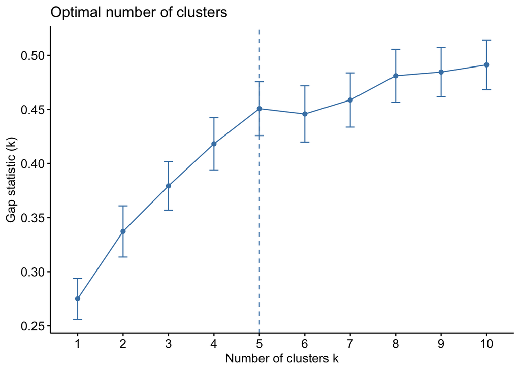

```r
# Uses the gap stat method to determine the ideal number of clusters
# The plot shows the optimal number is k = 5 clusters
set.seed(35)
fviz_nbclust(data, hcut, method = "gap_stat")
```

From the graph, we can see that the optimal number of clusters is five. Now, we can perform agglomerative hierarchical clustering. The way we can map out the hierarchical clustering process is with a tree-like diagram called a dendrogram.

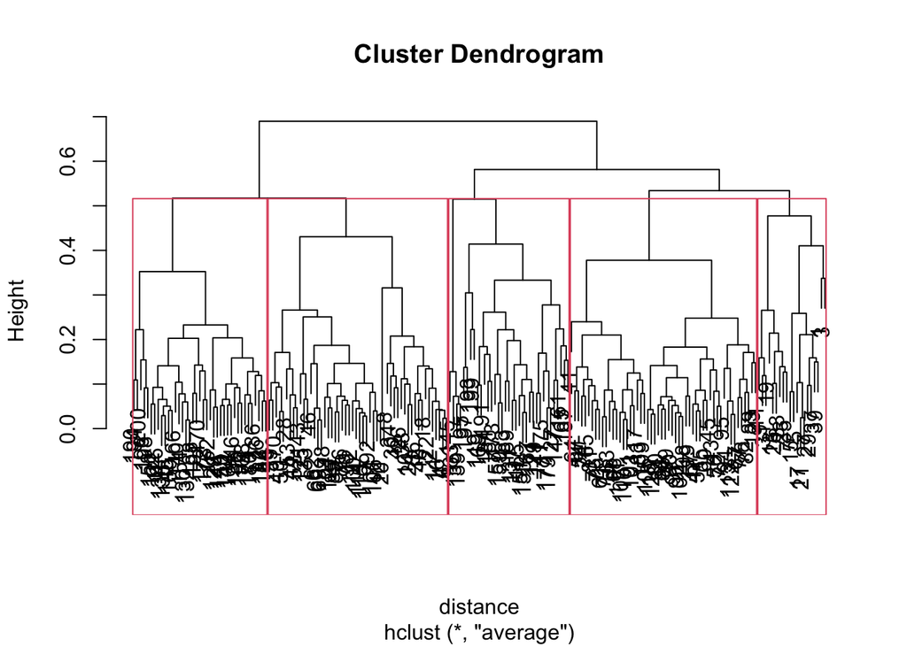

```r
# Calculates the average distance for each hierarchical cluster
set.seed(35)
distance = dist(data, method = "euclidean")
hier.average = hclust(distance, method = "average")

# Creates and plots a dendrogram to show the two clusters
plot(hier.average)
rect.hclust(hier.average, k = 5)
abline(h = 5, col = "red")
```

```r
# Identifies which variables are in which cluster
cluster.cut = cutree(hier.average, k = 5)

# Adds the cluster identifier to the dataset
data$Cluster = cluster.cut
```

The observations are at the bottom of the tree and the five clusters are separated by the red lines. We can then compute summary statistics for the five clusters.

```r
# Un-standardizes the data in order to put the variables back into their original units
data = read.csv("/Users/rolandgraham/Downloads/Mall_Customers.csv", header = TRUE)
colnames(data)[4] = "Income"
colnames(data)[5] = "Score"
data = data[,3:5]
data$Cluster = cluster.cut
```

```r
# Shows the summary statistics for the first cluster
summary(data$Age[data$Cluster == 1])
```

```
##    Min. 1st Qu.  Median    Mean 3rd Qu.    Max.
##   19.00   35.00   43.50   43.90   53.25   67.00
```

```r
summary(data$Income[data$Cluster == 1])
```

```
##    Min. 1st Qu.  Median    Mean 3rd Qu.    Max.
##   15.00   19.00   23.50   24.45   29.25   37.00
```

```r
summary(data$Score[data$Cluster == 1])
```

```
##    Min. 1st Qu.  Median    Mean 3rd Qu.    Max.
##    3.00    6.00   14.50   19.10   31.25   40.00
```

```r
# Shows the summary statistics for the second cluster
summary(data$Age[data$Cluster == 2])
```

```
##    Min. 1st Qu.  Median    Mean 3rd Qu.    Max.
##   18.00   21.00   23.50   24.65   28.25   35.00
```

```r
summary(data$Income[data$Cluster == 2])
```

```
##    Min. 1st Qu.  Median    Mean 3rd Qu.    Max.
##   15.00   28.00   41.00   42.94   60.00   76.00
```

```r
summary(data$Score[data$Cluster == 2])
```

```
##    Min. 1st Qu.  Median    Mean 3rd Qu.    Max.
##   29.00   49.75   58.00   62.08   75.25   99.00
```

```r
# Shows the summary statistics for the third cluster
summary(data$Age[data$Cluster == 3])
```

```
##    Min. 1st Qu.  Median    Mean 3rd Qu.    Max.
##   32.00   47.25   50.00   53.26   63.00   70.00
```

```r
summary(data$Income[data$Cluster == 3])
```

```
##    Min. 1st Qu.  Median    Mean 3rd Qu.    Max.
##   38.00   47.25   54.00   54.20   62.00   69.00
```

```r
summary(data$Score[data$Cluster == 3])
```

```
##    Min. 1st Qu.  Median    Mean 3rd Qu.    Max.
##   28.00   43.00   48.00   48.56   55.00   60.00
```

```r
# Shows the summary statistics for the fourth cluster
summary(data$Age[data$Cluster == 4])
```

```
##    Min. 1st Qu.  Median    Mean 3rd Qu.    Max.
##   27.00   30.00   32.00   32.69   35.50   40.00
```

```r
summary(data$Income[data$Cluster == 4])
```

```
##    Min. 1st Qu.  Median    Mean 3rd Qu.    Max.
##   69.00   75.50   79.00   86.54   95.00  137.00
```

```r
summary(data$Score[data$Cluster == 4])
```

```
##    Min. 1st Qu.  Median    Mean 3rd Qu.    Max.
##   63.00   74.50   83.00   82.13   90.00   97.00
```

```r
# Shows the summary statistics for the fifth cluster
summary(data$Age[data$Cluster == 5])
```

```
##    Min. 1st Qu.  Median    Mean 3rd Qu.    Max.
##   19.00   35.00   43.00   41.69   47.50   59.00
```

```r
summary(data$Income[data$Cluster == 5])
```

```
##    Min. 1st Qu.  Median    Mean 3rd Qu.    Max.
##   71.00   77.50   85.00   88.23   97.50  137.00
```

```r
summary(data$Score[data$Cluster == 5])
```

```
##    Min. 1st Qu.  Median    Mean 3rd Qu.    Max.
##    1.00   10.00   16.00   17.29   23.50   39.00
```

From comparing the five clusters, we can see that the clusters with the two highest spending scores were

1. People in their 30s with high income
2. People in their 20s with low to moderate income

The cluster with the third highest spending score was

3. People in their 50s with moderate income

And the clusters with the two lowest spending scores were

4. People in their 40s with low income
5. People in their 40s with high income

This means that from an age perspective, younger people tend to spend at this mall more than the older people given the divide in their spending scores. In terms of income, the two clusters are people who make $86,540 per year and $42,940 respectively. This means that products can be marketed to people whose income falls in the broad range of $40000-$90000 per year.